# Assignment 7 - Bicycle-Use Patterns

Felix Su

March 4, 2016

*Source file* ⇒ /Users/felixsu/ucb_classes/Sp16/STAT133/hw/hw7/Assignment-7-Su.Rmd  
Two data tables are available:

Stations gives the locations of the bike rental stations. Trips contains records of individual rentals. You can access the data like this.

```r
Stations <- mosaic::read.file("http://tiny.cc/dcf/DC-Stations.csv")
```

```
## Reading data with read.csv()
```

```r
data_site <- "http://tiny.cc/dcf/2014-Q4-Trips-History-Data.rds"
Trips <- readRDS(gzcon(url(data_site)))
```

## Time of day

It’s natural to expect that bikes are rented more at some times of day than others. The variable sdate gives the time (including the date) that the rental started.

Make these plots and interpret them: 1. A density plot of the events versus sdate. Your plot should look like:

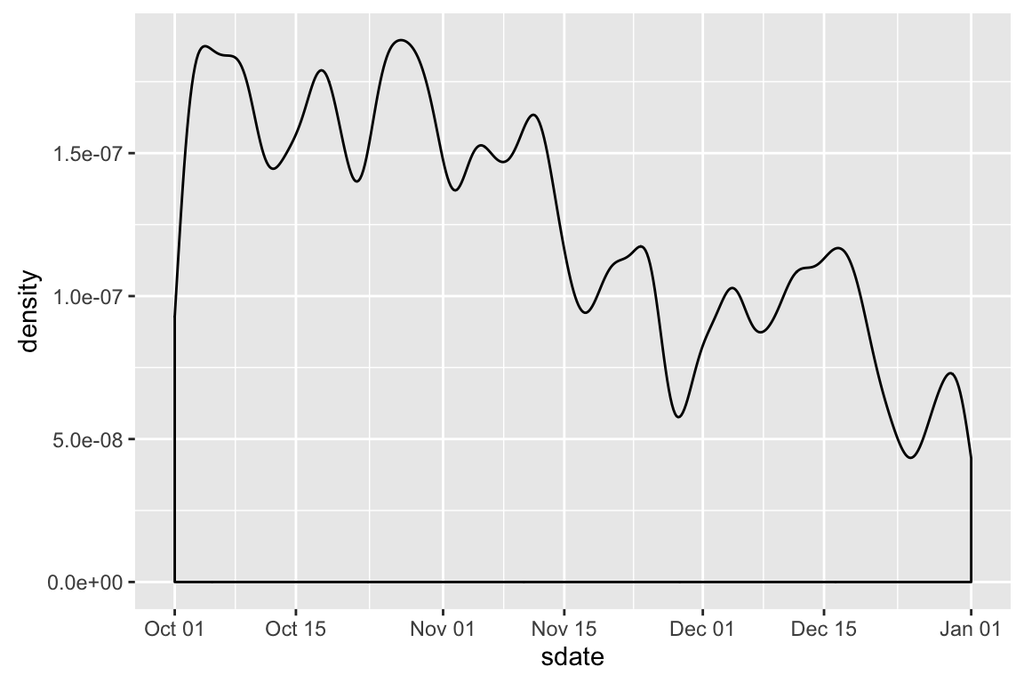

```r
Trips %>%
  ggplot(aes(x = sdate)) +
  geom_density()
```

2. A density plot of the events versus time of day. You can use lubridate::hour(), and lubridate::minute() to extract the hour of the day and minute within the hour from sdate, e.g.

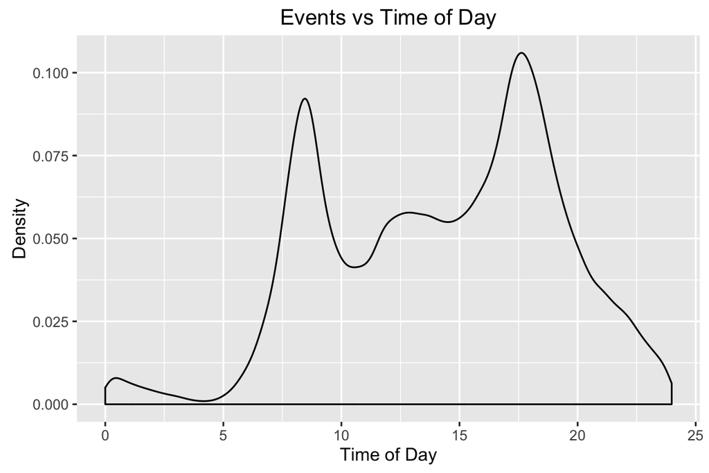

```r
Trips %>%
  mutate(time_of_day = lubridate::hour(sdate) + lubridate::minute(sdate) / 60) %>%
  ggplot(aes(x = time_of_day)) +
  geom_density() +
  xlab("Time of Day") + ylab("Density") + ggtitle("Events vs Time of Day")
```

3. Facet (2) by day of the week. (Use `lubridate::wday()` to generate day of the week.)

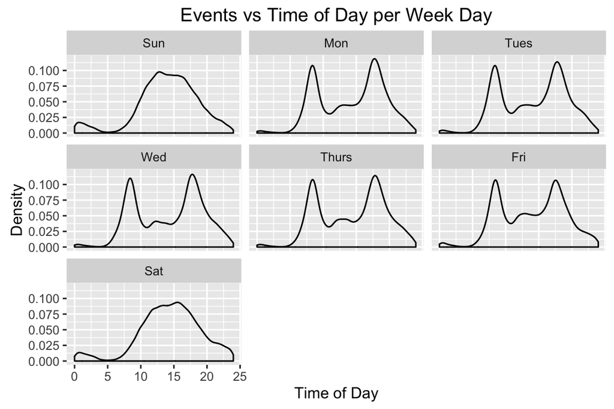

```r
Trips_wday <- Trips %>%
    mutate(time_of_day = lubridate::hour(sdate) + lubridate::minute(sdate) / 60,
           wday = lubridate::wday(sdate, label=TRUE))

Trips_wday %>%
    ggplot(aes(x = time_of_day)) +
    facet_wrap(~ wday) +
    geom_density() +
    xlab("Time of Day") + ylab("Density") + ggtitle("Events vs Time of Day per Week Day")
```

4. Set the `fill` aesthetic for `geom_density()` to the `client` variable.1 You may also want to set the `alpha` for transparency and `color=NA` to suppress the outline of the density function.

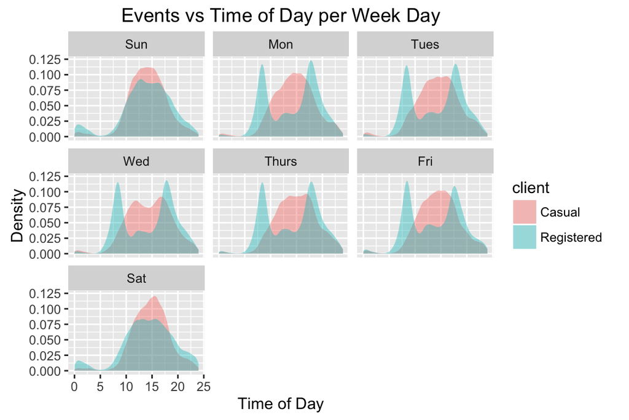

```r
Trips_wday %>%
    ggplot(aes(x = time_of_day)) +
    facet_wrap(~ wday) +
    geom_density(aes(fill=client), alpha = .4, color = NA) +
    xlab("Time of Day") + ylab("Density") + ggtitle("Events vs Time of Day per Week Day")
```

5. Same as (4) but using `geom_density()` with the argument `position = position_stack()`.
   - In your opinion, which of these graphics is most effective at telling an interesting story?

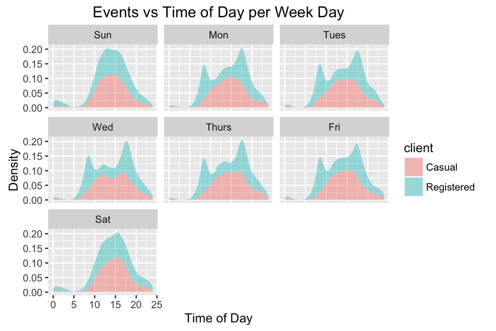

```r
Trips_wday %>%
    ggplot(aes(x = time_of_day)) +
    facet_wrap(~ wday) +
    geom_density(aes(fill=client),position = position_stack(), alpha = .4, color = NA) +
    xlab("Time of Day") + ylab("Density") + ggtitle("Events vs Time of Day per Week Day")
```

6. Rather than faceting on day of the week, consider creating a new faceting variable like this:

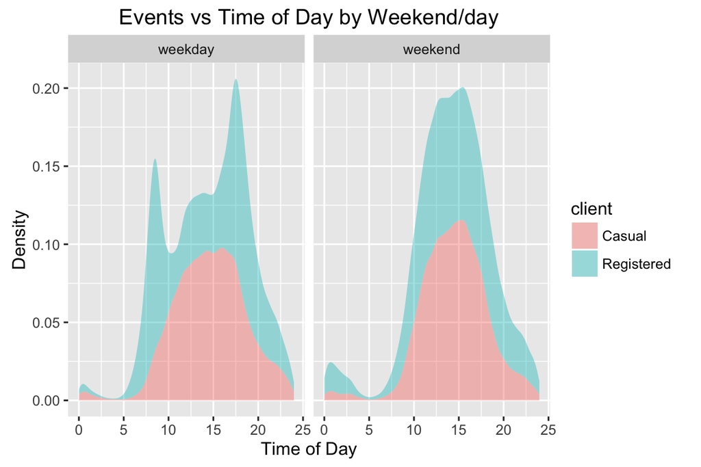

```r
Trips_wday_wknd <- Trips_wday %>%
    mutate(wday = ifelse(lubridate::wday(sdate) %in% c(1,7), "weekend", "weekday"))

Trips_wday_wknd %>%
    ggplot(aes(x = time_of_day)) +
    facet_wrap(~ wday) +
    geom_density(aes(fill=client),position = position_stack(), alpha = .4, color = NA) +
    xlab("Time of Day") + ylab("Density") + ggtitle("Events vs Time of Day by Weekend/day")
```

- Is it better to facet on `wday` and fill with `client`, or vice versa?

**It is better to facet on wday and fill with client, because this way, it shows that registered bikers and casual riders both make trips around noon during weekends, but while casual riders maintain the same pattern on weekdays, registered bikers tend to make trips in the morning and evenings instead of the afternoon on weekdays. If we facetted on client and filled with wday, the stacked nature of the graphs cause the density to be misleading, and not instantly understandable for the registered bikers on weekends.**

## Trip distance

How does the start-to-end trip distance depend on time of day, day of the week, and client?

1. Make two copies of `Stations`, which we’ll call `Left` and `Right`. `Left` will have names `sstation`, `lat`, and `long`. `Right` will have names `estation`, `lat2`, and `long2`. The other variables, `nbBikes` and `nbEmptyDocks` should be dropped. Use the function `dpylr::rename()` to do the renaming of name,lat, and long (i.e. `dyplyr::rename(sstation=name)`).

```r
Left <- Stations %>%
  select(name, lat, long) %>%
  rename(sstation = name)
Right <- Stations %>%
  select(name, lat, long) %>%
  rename(estation = name, lat2 = lat, long2 = long)
```

2. Join `Left` and `Right` with a full outer join. This is a join in which every case in Left is matched to every case in Right. You can accomplish the *full outer join* with `left%>% merge(right,all=TRUE)`.

```r
merged_stations <- Left %>% merge(Right, all=TRUE)
```

Of course, with the latitude and longitude of each station, you have enough information to calculate the distance between stations. This calculation is provided by the `haversine()` function, which you can load with

```r
source("http://tiny.cc/dcf/haversine.R")
```

Then …

3. Using the merged table, add a variable dist like this:

```r
Distances <- merged_stations %>%
  mutate(dist = haversine(lat, long, lat2, long2)) %>%
  select(estation,sstation,dist)
```

Join `Trips` to `Distances` to add a `dist` value for each trip.

```r
Trip_dists <- Trips_wday_wknd %>% left_join(Distances)
```

## Distributions of distances

1. Make a density plot of `dist` broken down by weekend vs weekday and by client.

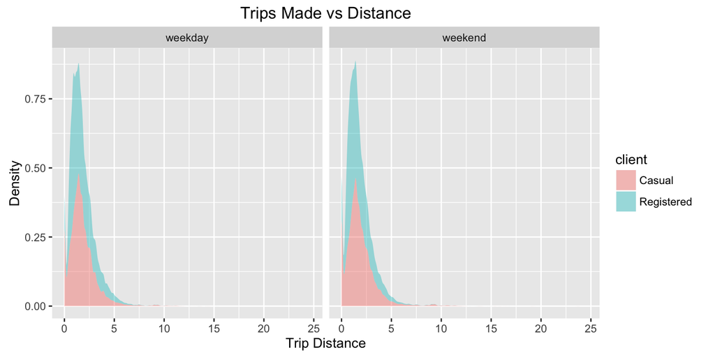

```r
Trip_dists %>%
    ggplot(aes(x = dist)) +
    facet_wrap(~ wday) +
    geom_density(aes(fill=client),position = position_stack(), alpha = .4, color = NA) +
    xlab("Trip Distance") + ylab("Density") + ggtitle("Trips Made vs Distance")
```

2. Show the distribution of `dist` in a compact way with a *violin* plot or *box and whiskers* plot.For both `geom_violin()` and `geom_boxplot()`, you will want to map the *group* aesthetic to *hour*. For `geom_boxplot()`, you may prefer to set `outlier.size = 1`. You might also want to add a `stat_smooth()` layer.

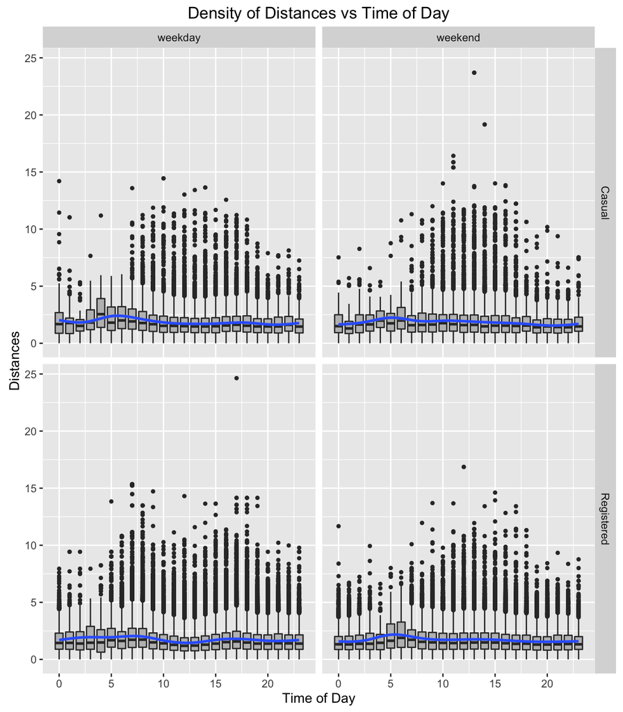

```r
Trip_dists %>%
    mutate(hour = lubridate::hour(sdate)) %>%
    ggplot(aes(x = hour, y = dist)) +
    facet_grid(client ~ wday) +
    geom_boxplot(aes(group=hour), position = position_dodge(width = 0.8), outlier.size = 1, fill = "gray") +
    stat_smooth() +
    xlab("Time of Day") + ylab("Distances") + ggtitle("Density of Distances vs Time of Day")
```